# BI transcriptome

AM

2026-04-03

```r
source("R/functions.R")
```

```r
# List Salmon output
samples <- list.files("../Salmon quant/Salmon quant", full.names = FALSE)
files <- file.path("../Salmon quant/Salmon quant", samples, "quant.sf")
names(files) <- samples
file.exists(files)
```

```
## [1] TRUE TRUE TRUE TRUE TRUE TRUE
```

```r
# Loading GTF
txdb <- makeTxDbFromGFF("../data/gencode.v47.annotation.gtf.gz")
k <- keys(txdb, keytype = "TXNAME")

# TXNAME → ENSG
tx2gene_ensg <- AnnotationDbi::select(txdb, k, "GENEID", "TXNAME")

# Cleaning up versions (removing .number)
tx2gene_ensg$GENEID_clean <- gsub("\\..*", "", tx2gene_ensg$GENEID)

# Add a column with gene symbols (using cleaned keys).
tx2gene_ensg$SYMBOL <- mapIds(org.Hs.eg.db,
                              keys = tx2gene_ensg$GENEID_clean,
                              column = "SYMBOL",
                              keytype = "ENSEMBL",
                              multiVals = "first")

# Replace GENEID with SYMBOL
tx2gene <- tx2gene_ensg[, c("TXNAME", "SYMBOL")]
colnames(tx2gene) <- c("TXNAME", "GENEID")

# Remove NA
tx2gene <- na.omit(tx2gene)

# Save
write.csv(tx2gene, "../data/tx2gene_symbols.csv", row.names = FALSE)
```

Import files and count genes:

```r
tx2gene <- read.csv("../data/tx2gene_symbols.csv")

txi_gene <- tximport(files, type = "salmon", tx2gene = tx2gene, countsFromAbundance="no")
txi_gene_RPK <- txi_gene$counts/txi_gene$length
txi_gene_TPM <-  tximport(files, type = "salmon", tx2gene = tx2gene, countsFromAbundance = "lengthScaledTPM")

txi_counts <- data.frame(txi_gene$counts)
txi_TPM <- data.frame(txi_gene_TPM$counts)
write.table(txi_counts, file = "raw_counts_all_samples.txt", sep = "\t", row.names = TRUE, quote = FALSE)
write.csv2(txi_counts, file = "raw_counts_all_samples.csv", row.names = TRUE, quote = FALSE)
write.csv2(txi_TPM, file = "TPM_all_samples.csv", row.names = TRUE, quote = FALSE)
```

Add information about samples

```
##                            cell_line condition
## Unknown_CG769-002U0029        HCT116 sensitive
## Unknown_CG769-002U0030        HCT116 sensitive
## Unknown_CG769-002U0031        HCT116 sensitive
## Unknown_CG769-002U0041 HCT116_oxpl_R resistant
## Unknown_CG769-002U0042 HCT116_oxpl_R resistant
## Unknown_CG769-002U0043 HCT116_oxpl_R resistant
```

```
## [1] "Intercept"                         "cell_line_HCT116_oxpl_R_vs_HCT116"
```

```
##
## out of 20913 with nonzero total read count
## adjusted p-value < 0.05
## LFC > 0 (up)       : 2871, 14%
## LFC < 0 (down)     : 2740, 13%
## outliers [1]       : 24, 0.11%
## low counts [2]     : 4460, 21%
## (mean count < 2)
## [1] see 'cooksCutoff' argument of ?results
## [2] see 'independentFiltering' argument of ?results
```

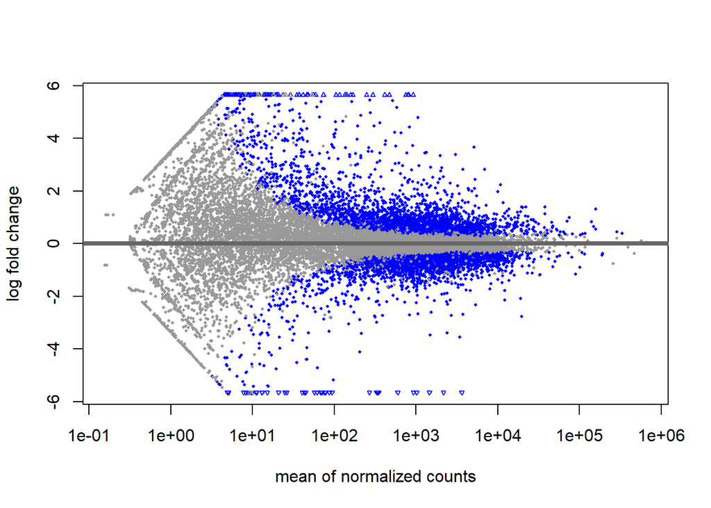

```r
plotMA(results)
```

The MA-plot illustrates the relationship between the magnitude of change (log2FC) and average gene expression. It reveals that the majority of genes remain unchanged, while significant changes are distributed symmetrically around zero

### gene-wise dispersion

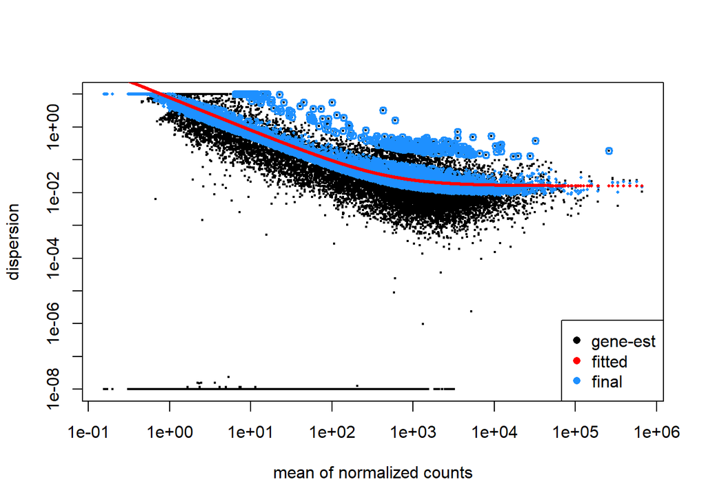

```r
plotDispEsts(dds)
```

The red line flows smoothly through the main cloud of points, and the majority of the points lie not too far from the line. This confirms that the dispersion model has been constructed correctly and that the DESeq2 results are reliable.

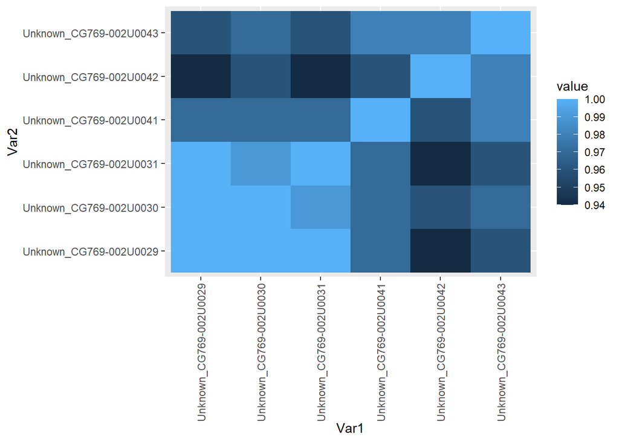

```r
cor_matrix <- round(cor(txi_gene$abundance, method = 'pearson'), 2)
melted_cormat <- reshape2::melt(cor_matrix)

ggplot(data = melted_cormat, aes(x=Var1, y=Var2, fill=value), trace="none") +
  geom_tile() + theme(axis.text.x = element_text(angle = 90, vjust = 0.5, hjust=1))
```

The correlation between replicates within groups was >0.98 for control samples and >0.95 for oxaliplatin-resistant samples, confirming the high reproducibility of the experiment. The correlation between groups is noticeably lower.

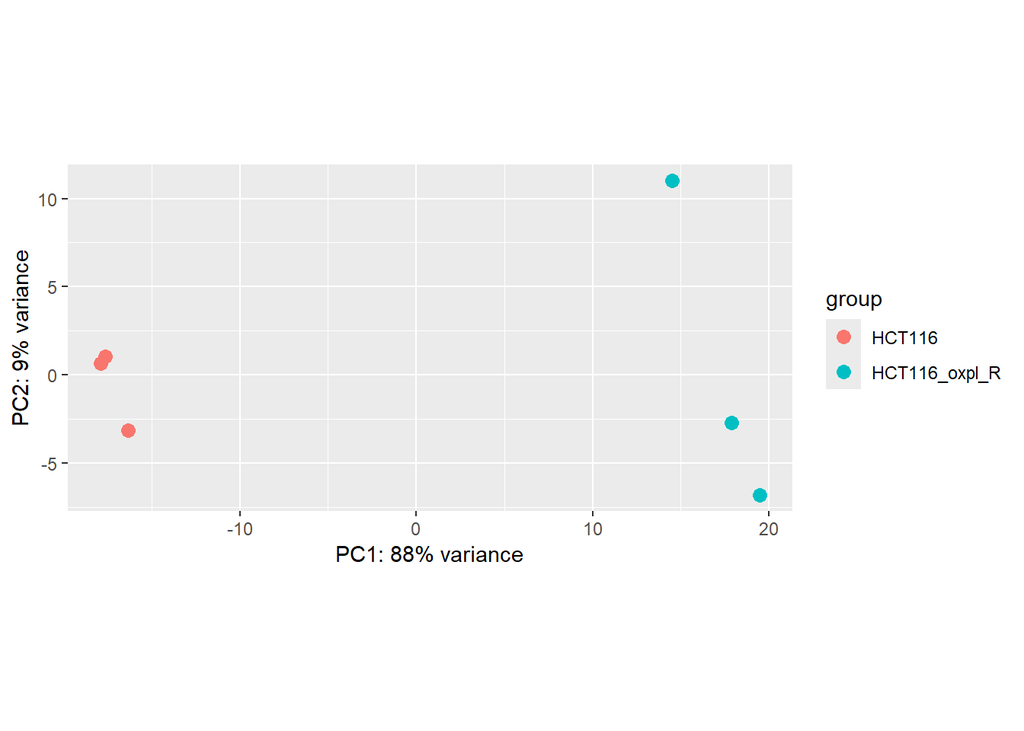

PCA reveals the extent to which samples resemble one another in a multidimensional space. The first principal component (PC1) explains 88% of the variance and clearly separates sensitive and resistant cells

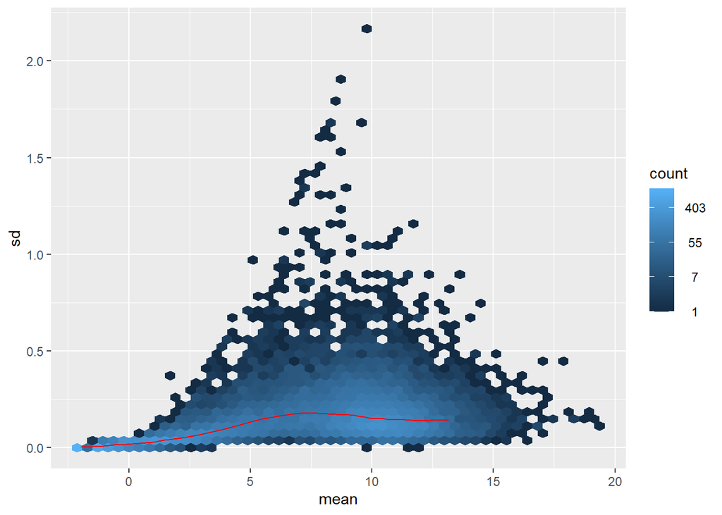

VST/rlog normalization successfully stabilized the variance, as confirmed by the diagnostic plot

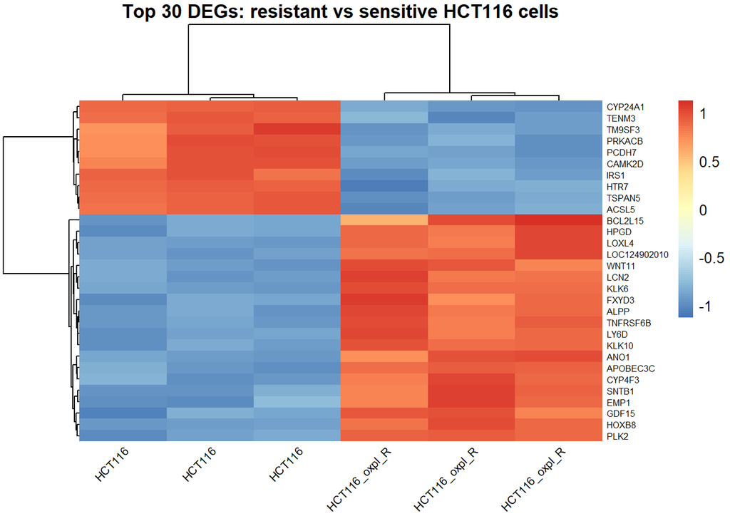

The heatmap of the top 30 DEGs visualizes the expression patterns of the most significant genes. Hierarchical clustering clearly separated the samples into two groups, and the genes into clusters with similar expression profiles.

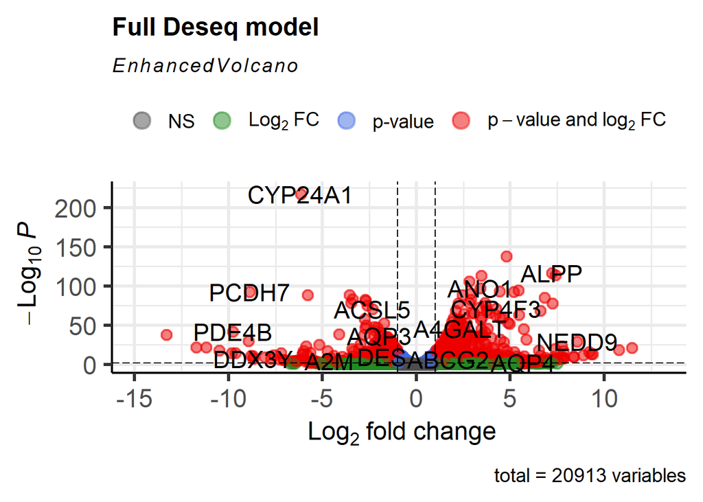

```r
EnhancedVolcano(results,
    lab = rownames(results),
    x = 'log2FoldChange',
    y = 'pvalue',
    pCutoffCol = "padj",
    title = 'Full Deseq model',
    FCcutoff = 1, pCutoff = 0.05,
    pointSize = 3.0,
    labSize = 6.0)
```

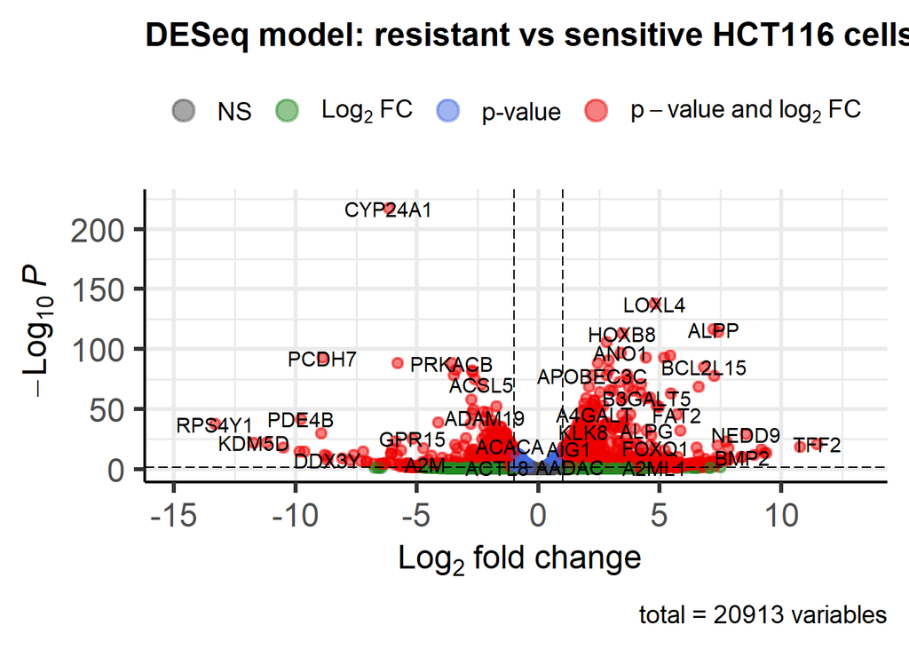

```r
plot_volcano(results, title = "DESeq model: resistant vs sensitive HCT116 cells")
```

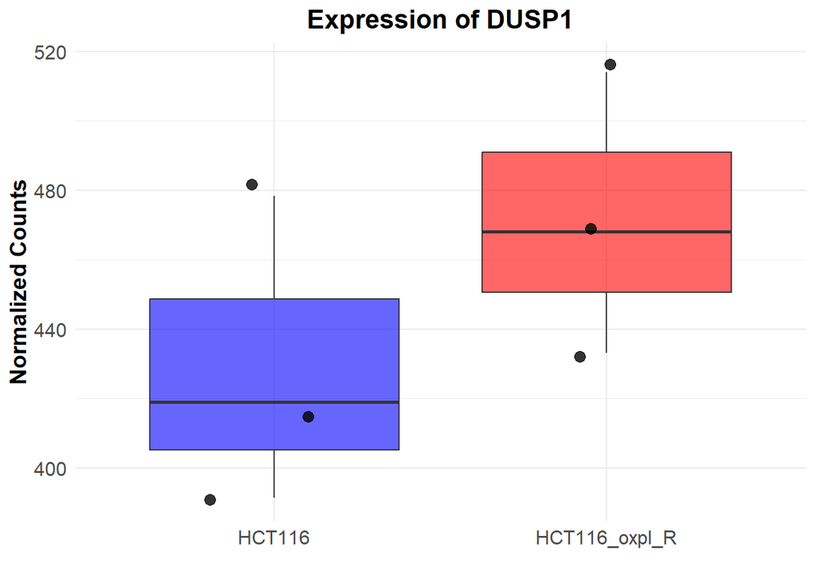

```r
markers <- c("DUSP1", "NSUN5P1", "RN7SK", "NDUFB7", "NDUFB5", "NDUFA2", "AKR1C2", "AKR1C3", "AHR", "CDKN1C", "GPX4")
gene <- markers[1]

ge <- plotCounts(dds, gene, intgroup = "cell_line", returnData = TRUE)
ggplot(ge, aes(x = cell_line, y = count, fill = cell_line)) +
  geom_boxplot(outlier.shape = NA, alpha = 0.6) +
  geom_jitter(width = 0.2, size = 3, alpha = 0.8) +
  scale_fill_manual(values = c("HCT116" = "blue", "HCT116_oxpl_R" = "red")) +
  labs(title = paste("Expression of", gene),
       x = "",
       y = "Normalized Counts") +
  theme_minimal() +
  theme(legend.position = "none",
        axis.text = element_text(size = 12),
        axis.title = element_text(size = 14, face = "bold"),
        plot.title = element_text(size = 16, face = "bold", hjust = 0.5))
```

Functional analysis based on the DESeq statistical metric:

```r
res_e1a <- results
gene_stat <- res_e1a$stat
names(gene_stat) <- rownames(res_e1a)
gene_stat <- na.omit(gene_stat)
gene_stat <- sort(gene_stat, decreasing = TRUE)

gene_list_entrez_stat <- gene_stat
mapping <- mapIds(org.Hs.eg.db,
                 keys = names(gene_stat),
                 column = "ENTREZID",
                 keytype = "SYMBOL",
                 multiVals = "first")

names(gene_list_entrez_stat) <- mapping

gene_list_entrez_stat <- na.omit(gene_list_entrez_stat)
gene_list_entrez_stat <- gene_list_entrez_stat[!is.na(names(gene_list_entrez_stat))]
```

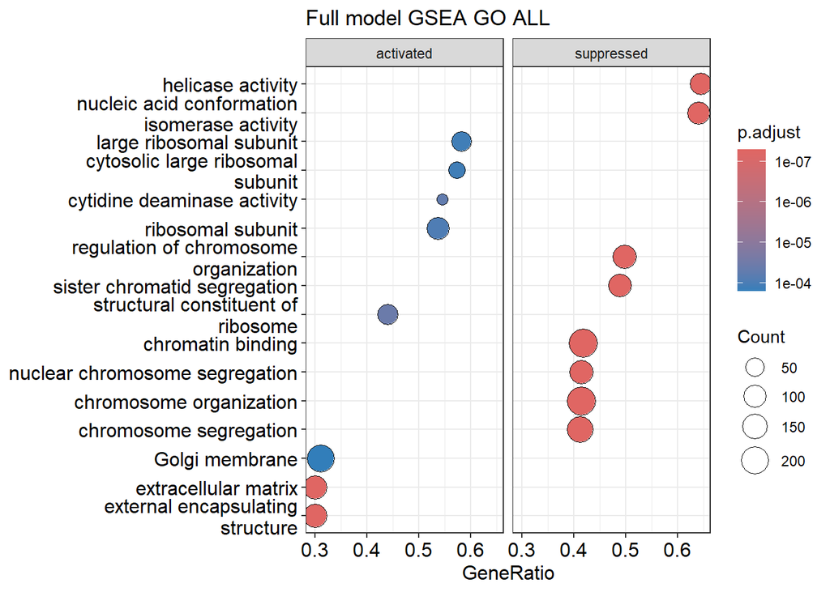

```r
# GSEA GO
gsea_results <- run_gsea_go(gene_stat, title_prefix = "Full model")

print(gsea_results$p1)
```

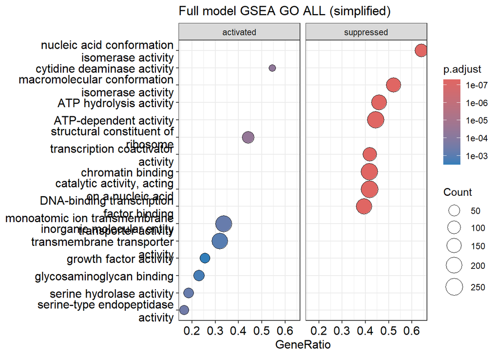

```r
print(gsea_results$p2)
```

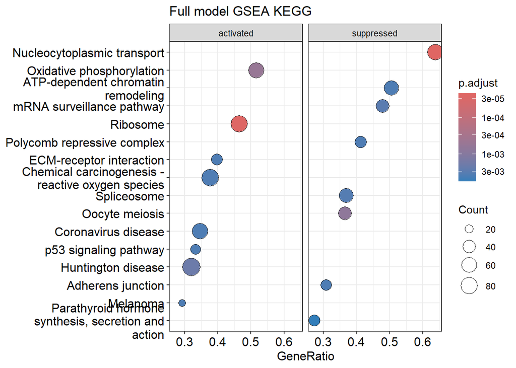

```r
# stat
# KEGG
kegg_results <- run_gsea_kegg(gene_list_entrez_stat, title_prefix = "Full model")

print(kegg_results$plot)
```

Even under control conditions (in the absence of oxaliplatin), resistant HCT116_oxpl_R cells differ from sensitive cells through the activation of pathways involved in energy metabolism, ribosome biogenesis, and adhesion, as well as the suppression of splicing, mRNA quality control, and chromatin remodeling. This basal difference may underlie their heightened resistance to oxaliplatin.

Functional Analysis — Transcription Factor Enrichment

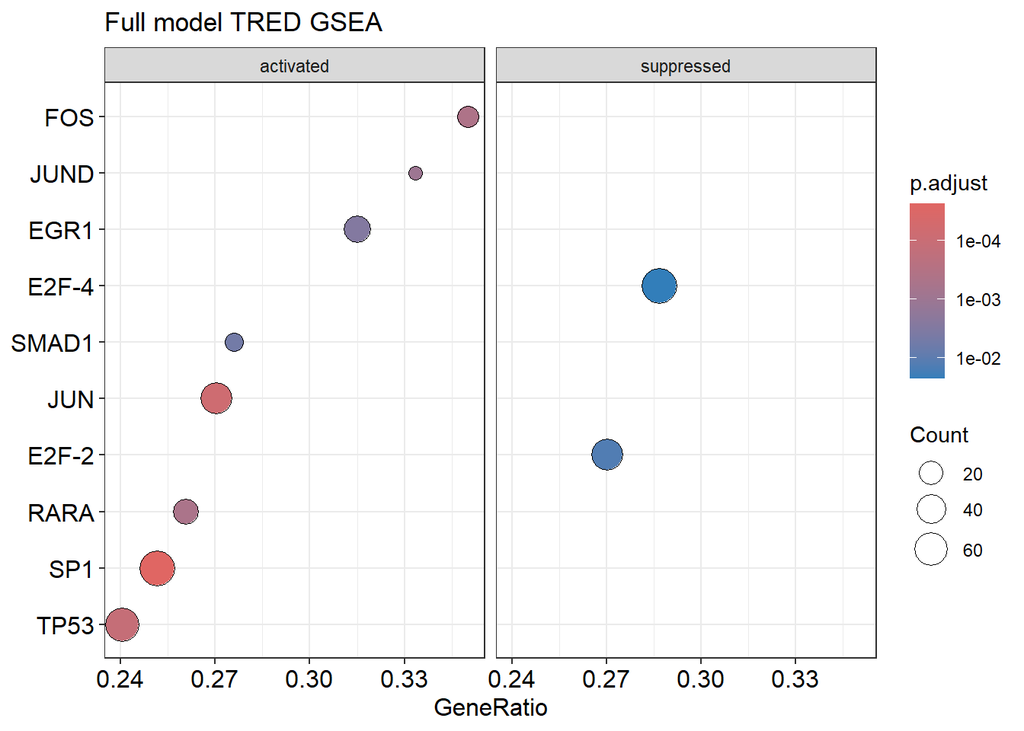

```r
# TRED
tred_results <- run_tred_gsea(gene_list_entrez_stat, title_prefix = "Full model")

print(tred_results$dotplot)
```

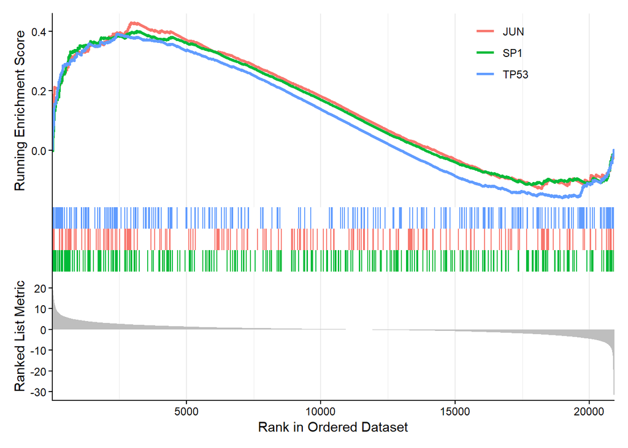

```r
print(tred_results$gseaplot)
```